# STAT/MATH 495: Problem Set 07

Tasheena Narraidoo

2017-10-24

Information on the competition can be found [here](https://www.kaggle.com/c/GiveMeSomeCredit/data).

# Collaboration

Please indicate who you collaborated with on this assignment: -

# Exploratory Data Analysis

We want to use the predictor that would best predict whether someone will experience financial distress in the next two years.

For our EDA, we will look at the distribution of each potential predictor variable to get an idea of the avaiable data. We notice that DebtRatio and MonthlyIncome are heavily skewed. So we will use log on these two variables. Since DebtRatio is a fraction, we will use log(x+1).

We next look at the relationship between our financial distress response variable with each potential variable. 1 indicates that the individual will be in finacial distress.

For Age distribution of financial situation of people, we see that younger people are more likely to be in serious financial distress within two years as compared to older people. This is what we would expect this older people are more likely to be financially stable and know how to manage their money.

The distribution of people in financial distress based on monthly income seem to be normal. Those in the middle bracket of our data are more likely to find themselves in financial distress. Those with lower income sometimes are not eligible for credit payments and those with higher income can cover their debt.

The data for Debt Ratio is still heavily skewed after log transform. We see that most data points are concentrated near 0.

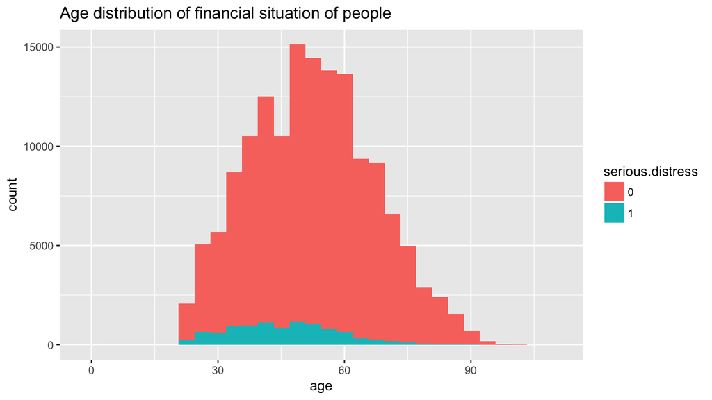

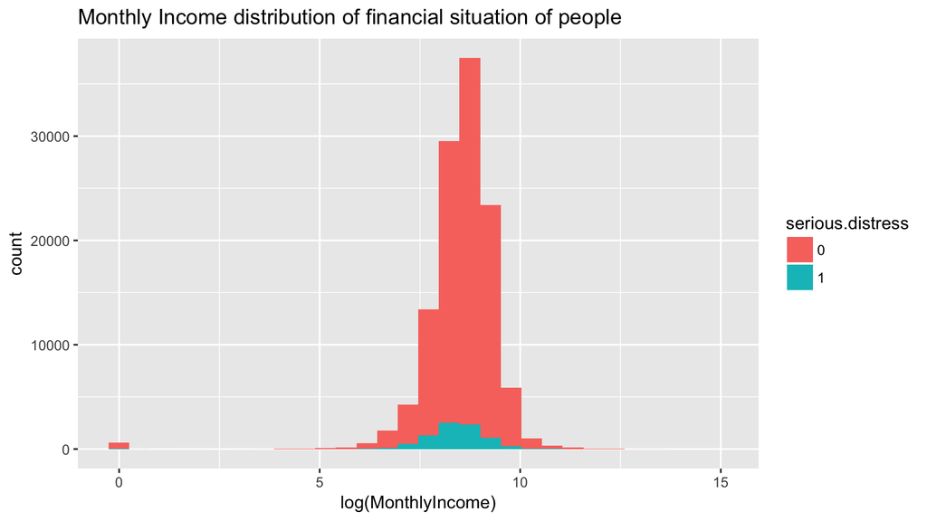

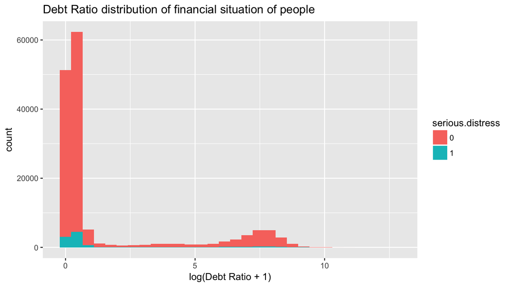

We next plot boxplots.

We see that the distributions of Monthly Income for each group (those who will be in financial difficulty and those who won’t) are similar with the median, upper quartiles and lower quartiles having nearly the same value. The same can be said for the Debt Ratio boxplots. However, the difference in distribution for `Age` is more pronounced.

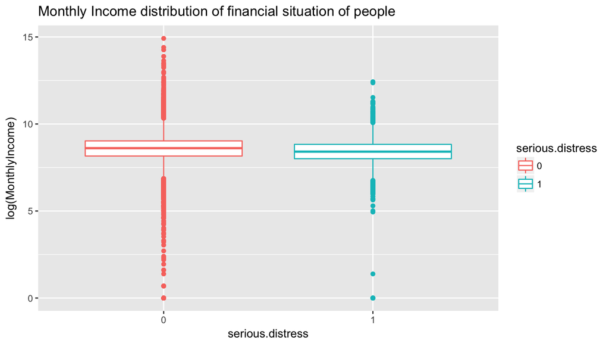

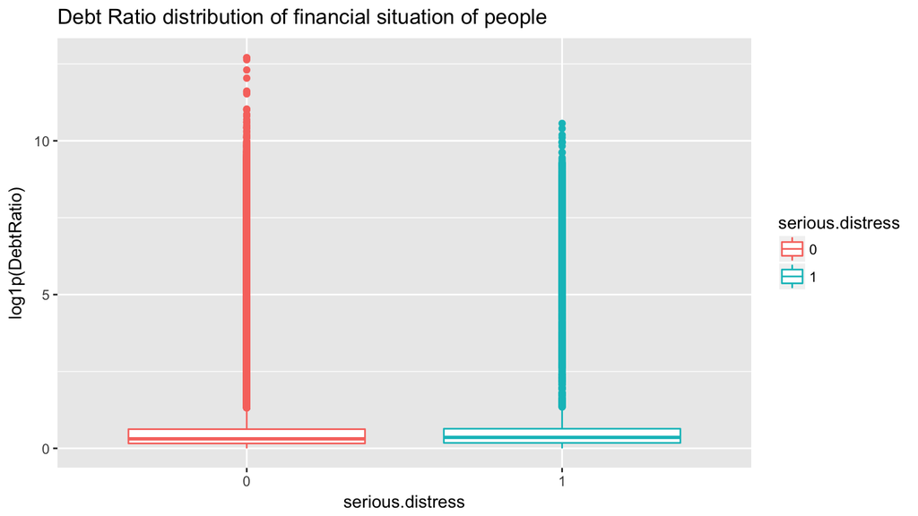

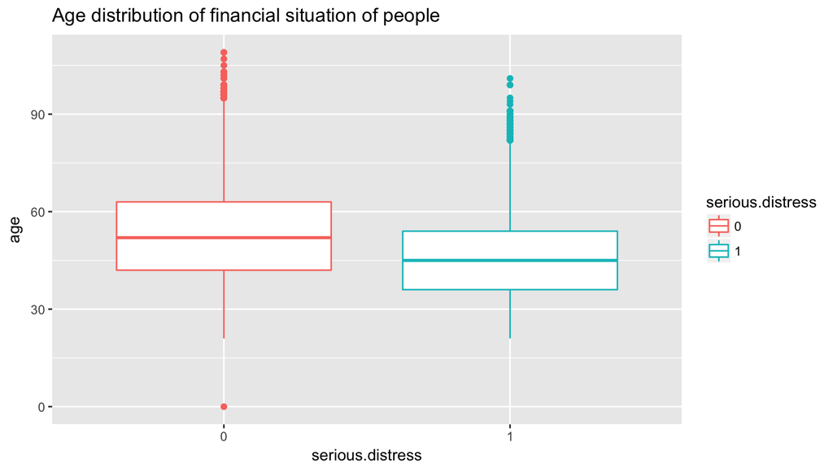

# Build binary classifier

Build the binary classifier based on a single predictor variable: `DebtRatio`, `age`, or `MonthlyIncome`. Justify this choice.

From the EDA, we eliminate `DebtRatio` and `MonthlyIncome` because from the boxplots we see that it would be hard two differentiate between the to categories. For `age` the boxplots had more visible differences. Hence, we will use `age` as our predictor variable.

`age` would be a good predictor variable as we would expect the age of people to affect financial judgement ability of people, with younger people still learning how to make good financial choices.

```r
# fit on train data
m1 <- glm(serious.distress ~ age, data=train, family = binomial)
```

# ROC curve

Based on the ultimate classifier you choose, plot a corresponding ROC curve.

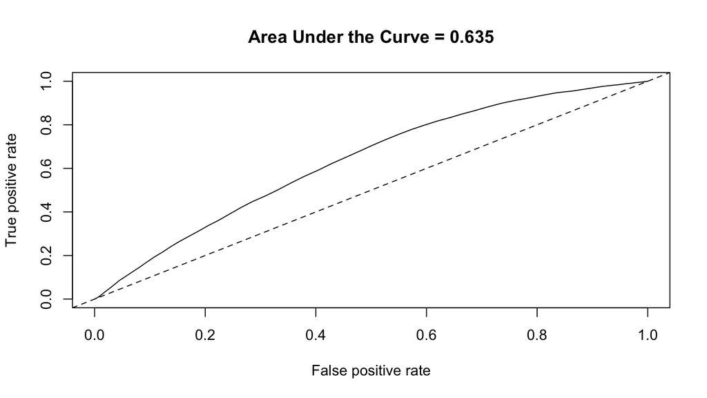

# ROC curve for random guessing

Instead of using any predictor information as you did above, switch your predictions to random guesses and plot the resulting ROC curve.

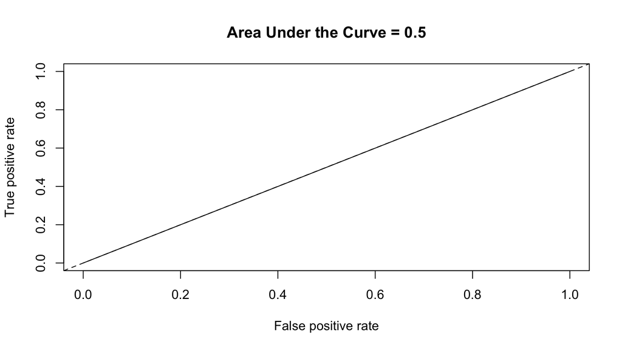